# Univariate Plots Section

# Multivariate Analysis

### Talk about some of the relationships you observed in this part of the investigation. Were there features that strengthened each other in terms of looking at your feature(s) of interest?

alcohol越高,volatitle.acidity越低对红酒的质量起了积极的作用。

### Were there any interesting or surprising interactions between features?

密度对红酒质量的影响不大。

# Final Plots and Summary

### Plot One

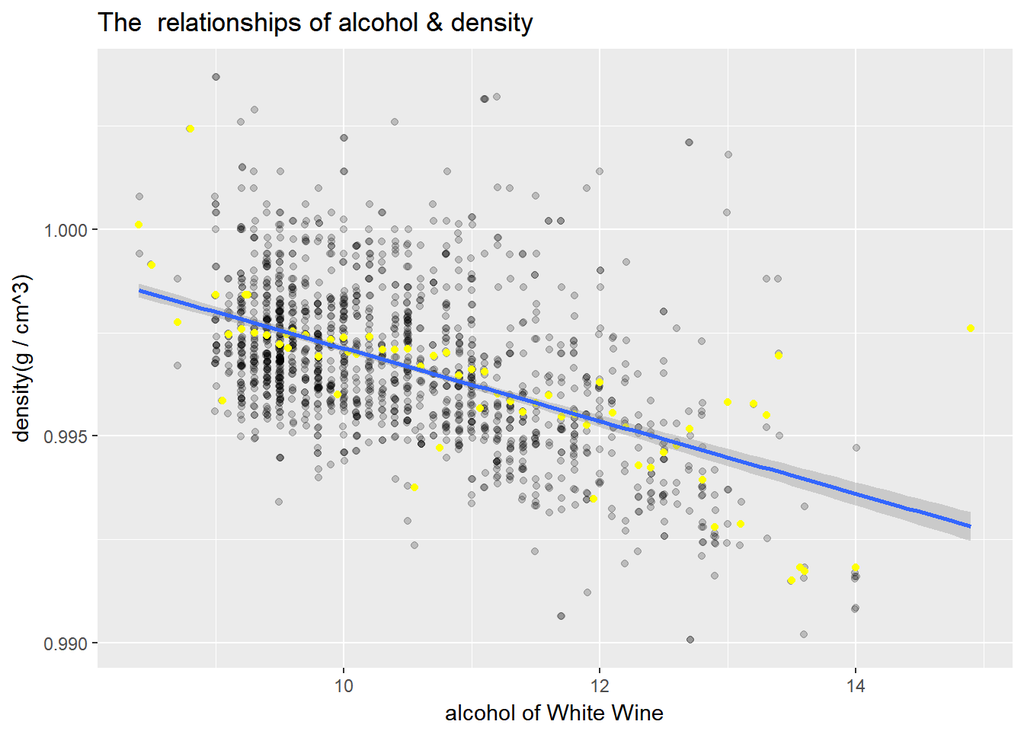

### Description One

由图可知，alchol与density呈负相关。alchol越高，density越低。和我们的常识相符，酒精的密度比水小。

### Plot Two

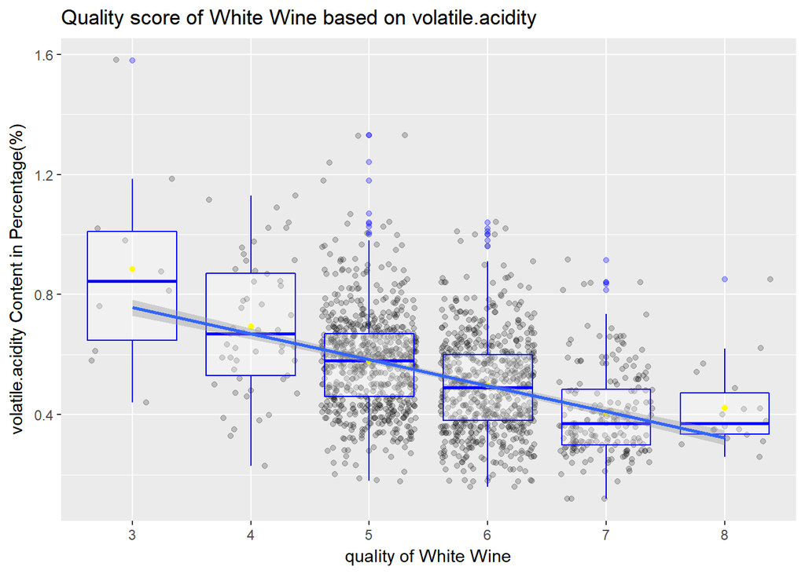

### Description Two

有图可得：一般来说，volatile.acidity含量越低，红酒质量得分越高。

### Plot Three

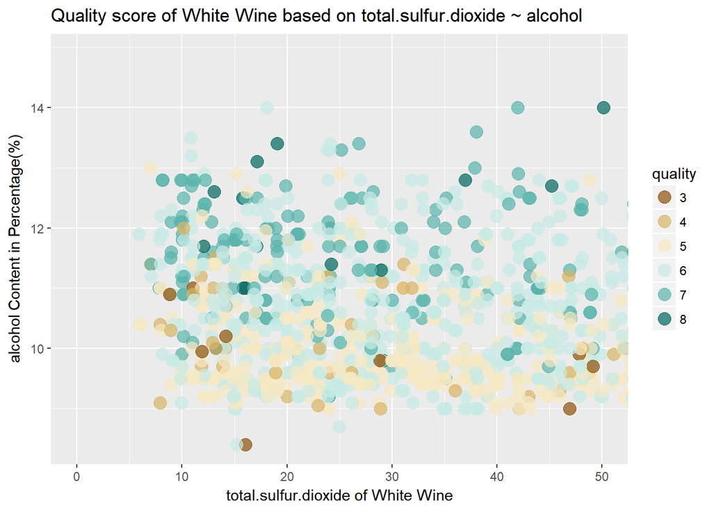

### Description Three

一般来说，alcohol较高的，红酒质量得分较高。total.sulfur.dioxide与红酒质量的相关度不大。

# Reflection

```
在探索一个变量的阶段，观察了下12个变量的分布情况。当时除了知道quality是重要变量，对其他变量的情况还不太了解。在探索两个变量时，拿11个变量分别和quality做了相关系数。得到酒精度，挥发性酸与quality有中等相关度。通过画箱线图和线性回归，也可以看到规律。在多个变量探索时，明确了高酒精度和低挥发度对得到高质量红酒有积极作用。
困难或成功：红酒的物理化学性质对红酒的质量不了解，入手稍慢。分析了各个变量和quality的相关系数后，才有了初步的方向。
数据比较集中在中等质量的，未来增加数据样本样。或者更加了解业务（即红酒的物理性质对质量的影响），可能能发现更多的信息，更准确的预测。
```